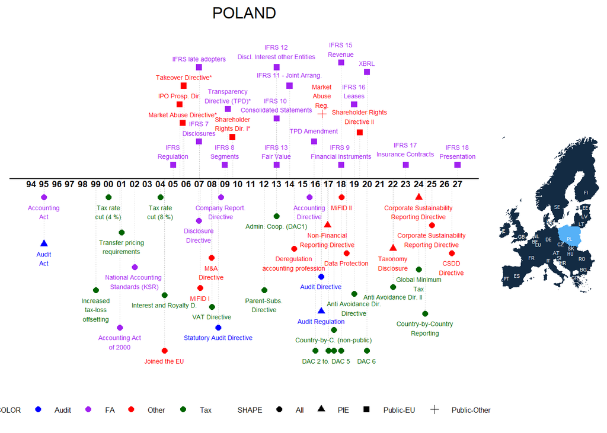

Notes: The graph depicts major regulatory changes that we identified via an extensive literature search, an online survey of mentioned authors, and other sources. Please note that the graph does not include all possible regulatory changes, e.g. minor revisions to local GAAP or tax rate changes below 3% are not included. The dates of EU Directives are based on the official transposition deadlines unless denoted with a *, in which case we included the entry-to-force date as identified in the literature. For more information, please go to [Labro and Pierk (2023)](http://www.eu-regulations.com/Labro_Pierk_2023.pdf). We kindly ask that you cite the paper if you use the information on this website in your research project. Do you have comments or see anything missing? Please email us!

## Regulations, Publications, Further Graphs

The tab ‘Regulations’ includes links to the regulations, gives short descriptions, and provides selective papers for further reading. If the regulation is a national transposition of an EU Directive, the link to the Directive is given. The tab ‘Number of Regulations’ shows graphically the number of regulations 8 years around the respective year (-4,-3,-2,-1,0,+1,+2,+3). The tab ‘Number of Categories” shows graphically the number of different categories 8 years around the respective year (-4,-3,-2,-1,0,+1,+2,+3). The tab ’Publications’ shows all publications that include the countries’ names and variations thereof in the title, abstract, or keywords. Similarly, the tab ‘SSRN’ shows papers of the SSRN Accouning Research Network that include the countries’ names and variations.

### Regulations

[output not shown]

[output cut: 51 more lines]

### Number of Regulations

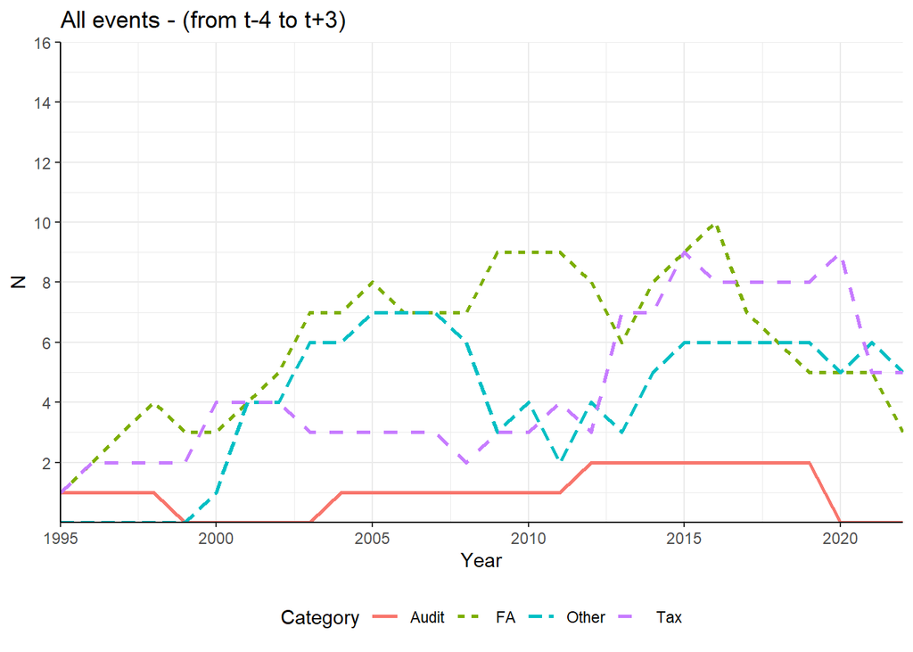

### Number of Categories

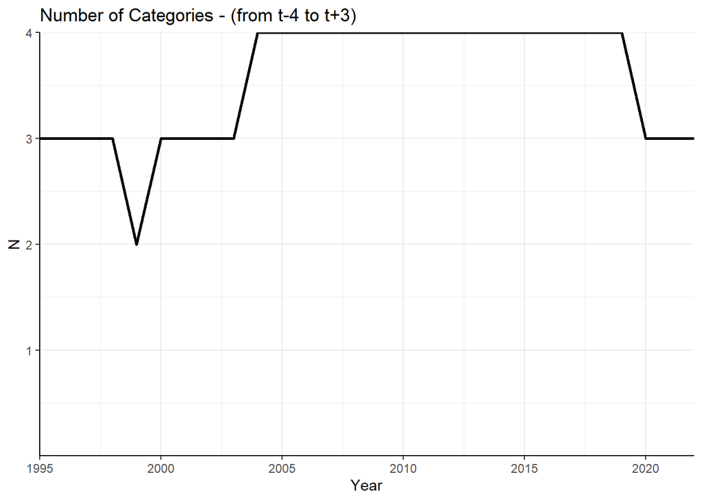

### Publications

|  | authors | title | year | journal |
| --- | --- | --- | --- | --- |
| 1 | Roszkowska P., Langer L.K., Langer P.B. | pension funds and ipo pricing. evidence from a quasi-experiment | 2021 | British Accounting Review |
| 2 | Łada M., Kozarkiewicz A., Haslam J. | contending institutional logics, illegitimacy risk and management accounting: a case study analysis of study programme calculations in a polish public university | 2020 | Accounting, Auditing and Accountability Journal |
| 3 | Dobija D., Górska A.M., Grossi G., Strzelczyk W. | rational and symbolic uses of performance measurement: experiences from polish universities | 2019 | Accounting, Auditing and Accountability Journal |
| 4 | Dumitru M., Dyduch J., Gușe R.-G., Krasodomska J. | corporate reporting practices in poland and romania–an ex-ante study to the new non-financial reporting european directive | 2017 | Accounting in Europe |
| 5 | Hadro D., Klimczak K.M., Pauka M. | impression management in letters to shareholders: evidence from poland | 2017 | Accounting in Europe |
| 6 | Klimczak K.M., Krasodomska J. | the role and current status of ifrs in the completion of national accounting rules–evidence from poland | 2017 | Accounting in Europe |
| 7 | Wieczynska M. | the ""big"" consequences of ifrs: how and when does the adoption of ifrs benefit global accounting firms? | 2016 | Accounting Review |
| 8 | Czarniawska B. | accounting and gender across times and places: an excursion into fiction | 2008 | Accounting, Organizations and Society |
| 9 | Bonsón E., Escobar T. | digital reporting in eastern europe: an empirical study | 2006 | International Journal of Accounting Information Systems |
| 10 | Kosmala K. | true and fair view or rzetelny i jasny obraz 1? a survey of polish practitioners | 2005 | European Accounting Review |

[output cut: 11 more lines]

### SSRN

|  | authors | title | Posted | Revised |
| --- | --- | --- | --- | --- |
| 1 | Grzegorz Mikołajewicz | the initial public offerings (ipo) on the warsaw stock exchange in the years 2006, 2007. the issue costs and the value of the discount rate for lack of marketability (dlom) | 2021-12-15 |  |
| 2 | Bohumil Král, Grzegorz Mikołajewicz, Jarosław Nowicki and Libuše Šoljaková | management accountants' professional competences: requirements in the czech republic and poland. the normative approach and business practice | 2021-11-18 | 2021-12-15 |
| 3 | Irena Jindrichovska and Vyacheslav Moskalchuk | influence of corporate taxation on the financial leverage of czech, polish and russian companies | 2020-07-21 |  |
| 4 | Maciej Konrad Dudek | optimal labor income taxation in poland - the case of high income earners | 2020-07-09 |  |